# PCA

# Задание 3.

Несмотря на то, что неформальный критерий ( что кумулятивная вариация компонент должна составлять 75%) показал, что применение МГК не совсем целесообразно, так как такая вариация набиралась больше, чем на двух компонентах, другие критерии могут выбрать другой порог.

Допустим, критерий Кайзера основывается на том, что нужно извлекать столько компонент,сколько собственных значений превышает 1. Это основано на том, что вариация одного стандартизированного показателя как раз будет 1, а если вариация компоненты больше 1, то она является достаточно информативной, чтобы объяснить больше одного показателя.

```r
std_dev <- pca_results$sdev
var <- std_dev^2
var
```

```
## [1] 3.0783391 1.5123081 0.9282684 0.7313011 0.6866768 0.6121115 0.5394319
## [8] 0.4865138 0.4250495
```

Таким образом, согласно критерию Кайзера для извлечения подходят первые две компоненты, так как их вариации ( собственные числа) превышают 1.

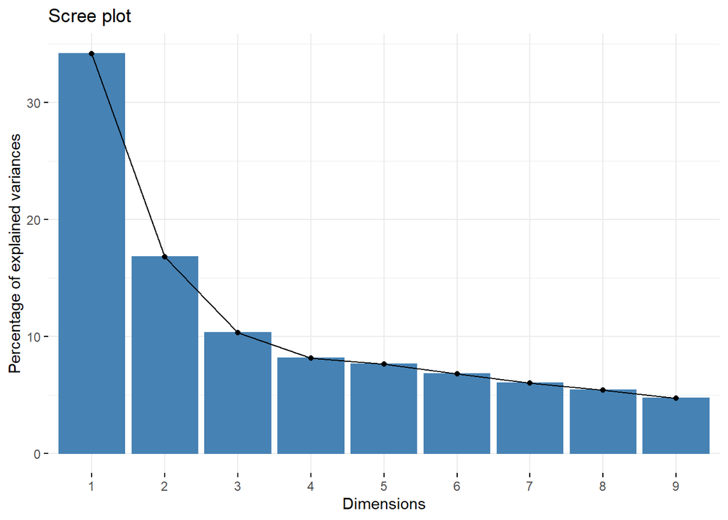

```r
fviz_eig(pca_results)
```

Согласно критерию Кеттела подтверждается, что нужно извлечь 2 компоненты, так как после этого идет переломная точка на 3 и прирост кумулятивной дисперсии замедляется.